# Stellar Prediction

In the field of astronomy, stellar classification involves categorizing stars according to their spectral characteristics. This classification system is crucial in understanding celestial objects. The initial cataloging of stars and their spatial distribution contributed to the realization that they constitute our Milky Way galaxy. As telescopes advanced, distinguishing Andromeda as a separate galaxy spurred the survey of numerous galaxies. The objective of this dataset is to classify stars, galaxies, and quasars by analyzing their spectral features.

## Dataset

The dataset comprises 100,000 observations captured by the Sloan Digital Sky Survey (SDSS). Each observation is defined by 17 featurs and 1 classtype indicating whether it corresponds to a star, galaxy, or quasar.

- obj_ID = Object Identifier, the unique value that identifies the object in the image catalog used by the CAS
- alpha = Right Ascension angle (at J2000 epoch)
- delta = Declination angle (at J2000 epoch)
- u = Ultraviolet filter in the photometric system
- g = Green filter in the photometric system
- r = Red filter in the photometric system
- i = Near Infrared filter in the photometric system
- z = Infrared filter in the photometric system
- run_ID = Run Number used to identify the specific scan
- rereun_ID = Rerun Number to specify how the image was processed
- cam_col = Camera column to identify the scanline within the run
- field_ID = Field number to identify each field
- spec_obj_ID = Unique ID used for optical spectroscopic objects
- class = object class (galaxy, star or quasar object)
- redshift = redshift value based on the increase in wavelength
- plate = plate ID, identifies each plate in SDSS
- MJD = Modified Julian Date, used to indicate when a given piece of SDSS data was taken
- fiber_ID = fiber ID that identifies the fiber that pointed the light at the focal plane in eac observation

## Goal

The primary goal for this project is to predict the class type of stellar via spectral characteristics captured, which is infact dealing with a **classification** problem and a **clustering** problem.n

```python
import numpy as np
import pandas as pd
import matplotlib.pyplot as plt
import seaborn as sns
```

```python
sns.set_context('notebook', font_scale=1.25, rc={'lines.linewidth': 2.5})
sns.set_style('white')
np.random.seed(123)  # For reproducibility
```

```python
import kaggle
kaggle.api.authenticate()

kaggle.api.dataset_download_files(
    'fedesoriano/stellar-classification-dataset-sdss17',
    path='./data',
    quiet=False,
    unzip=True
)
```

```
Downloading stellar-classification-dataset-sdss17.zip to ./data
```

# Data Visualization and Preprocessing

```python
dataset = pd.read_csv('./data/star_classification.csv')
dataset.head()
```

|  | obj_ID | alpha | delta | u | g | r | i | z | run_ID | rerun_ID | cam_col | field_ID | spec_obj_ID | class | redshift | plate | MJD | fiber_ID |
| --- | --- | --- | --- | --- | --- | --- | --- | --- | --- | --- | --- | --- | --- | --- | --- | --- | --- | --- |
| 0 | 1.237661e+18 | 135.689107 | 32.494632 | 23.87882 | 22.27530 | 20.39501 | 19.16573 | 18.79371 | 3606 | 301 | 2 | 79 | 6.543777e+18 | GALAXY | 0.634794 | 5812 | 56354 | 171 |
| 1 | 1.237665e+18 | 144.826101 | 31.274185 | 24.77759 | 22.83188 | 22.58444 | 21.16812 | 21.61427 | 4518 | 301 | 5 | 119 | 1.176014e+19 | GALAXY | 0.779136 | 10445 | 58158 | 427 |
| 2 | 1.237661e+18 | 142.188790 | 35.582444 | 25.26307 | 22.66389 | 20.60976 | 19.34857 | 18.94827 | 3606 | 301 | 2 | 120 | 5.152200e+18 | GALAXY | 0.644195 | 4576 | 55592 | 299 |
| 3 | 1.237663e+18 | 338.741038 | -0.402828 | 22.13682 | 23.77656 | 21.61162 | 20.50454 | 19.25010 | 4192 | 301 | 3 | 214 | 1.030107e+19 | GALAXY | 0.932346 | 9149 | 58039 | 775 |
| 4 | 1.237680e+18 | 345.282593 | 21.183866 | 19.43718 | 17.58028 | 16.49747 | 15.97711 | 15.54461 | 8102 | 301 | 3 | 137 | 6.891865e+18 | GALAXY | 0.116123 | 6121 | 56187 | 842 |

```python
dataset.info()
```

```
<class 'pandas.core.frame.DataFrame'>
RangeIndex: 100000 entries, 0 to 99999
Data columns (total 18 columns):
 #   Column       Non-Null Count   Dtype
---  ------       --------------   -----
 0   obj_ID       100000 non-null  float64
 1   alpha        100000 non-null  float64
 2   delta        100000 non-null  float64
 3   u            100000 non-null  float64
 4   g            100000 non-null  float64
 5   r            100000 non-null  float64
 6   i            100000 non-null  float64
 7   z            100000 non-null  float64
 8   run_ID       100000 non-null  int64
 9   rerun_ID     100000 non-null  int64
 10  cam_col      100000 non-null  int64
 11  field_ID     100000 non-null  int64
 12  spec_obj_ID  100000 non-null  float64
 13  class        100000 non-null  object
 14  redshift     100000 non-null  float64
 15  plate        100000 non-null  int64
 16  MJD          100000 non-null  int64
 17  fiber_ID     100000 non-null  int64
dtypes: float64(10), int64(7), object(1)
memory usage: 13.7+ MB
```

## Feature selection

By examining how the distribution of each feature is related to **class**, we can reduce the dimension of feature space and optimize the model performance. Here we make a simple observation about the **kde** curves:

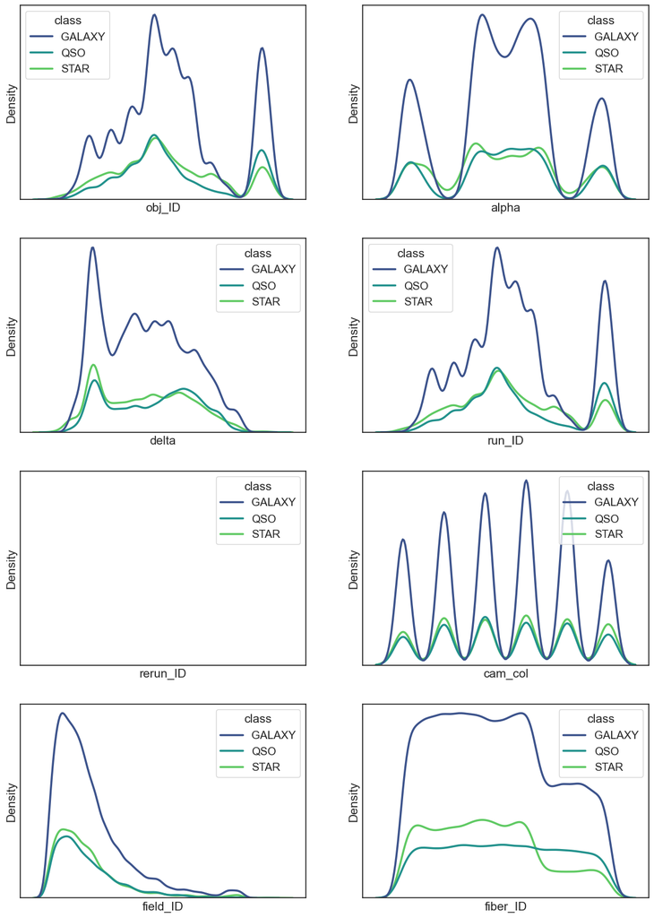

```python
fig, ax = plt.subplots(4, 2)

sns.kdeplot(data=dataset, x='obj_ID', hue='class', palette='viridis', ax=ax[0,0])

sns.kdeplot(data=dataset, x='alpha', hue='class', palette='viridis', ax=ax[0,1])

sns.kdeplot(data=dataset, x='delta', hue='class', palette='viridis', ax=ax[1,0])

sns.kdeplot(data=dataset, x='run_ID', hue='class', palette='viridis', ax=ax[1,1])

sns.kdeplot(data=dataset, x='rerun_ID', hue='class', palette='viridis', ax=ax[2,0], warn_singular=False)

sns.kdeplot(data=dataset, x='cam_col', hue='class', palette='viridis', ax=ax[2,1])

sns.kdeplot(data=dataset, x='field_ID', hue='class', palette='viridis', ax=ax[3,0])

sns.kdeplot(data=dataset, x='fiber_ID', hue='class', palette='viridis', ax=ax[3,1])

plt.setp(plt.gcf().get_axes(), xticks=[], yticks=[])

fig.set_figheight(20)
fig.set_figwidth(14)
```

where **rerun_ID** has no kde curve since it is single valued:

```python
dataset.value_counts('rerun_ID')
```

```
rerun_ID
301    100000
Name: count, dtype: int64
```

The distributions of features above do not really depend on class types. We will not consider them further. In contrast:

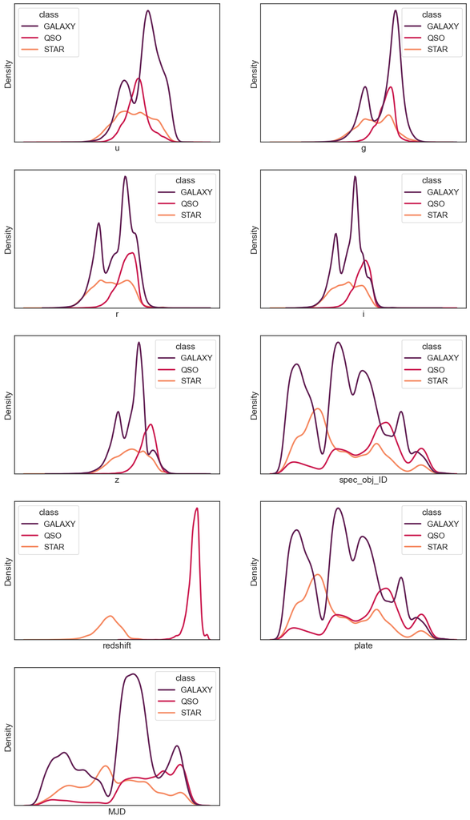

```python
fig, ax = plt.subplots(5, 2)

sns.kdeplot(data=dataset, x='u', log_scale=2, hue='class', palette='rocket', ax=ax[0,0])

sns.kdeplot(data=dataset, x='g', log_scale=2, hue='class', palette='rocket', ax=ax[0,1])

sns.kdeplot(data=dataset, x='r', hue='class', palette='rocket', ax=ax[1,0])

sns.kdeplot(data=dataset, x='i', hue='class', palette='rocket', ax=ax[1,1])

sns.kdeplot(data=dataset, x='z', log_scale=2, hue='class', palette='rocket', ax=ax[2,0])

sns.kdeplot(data=dataset, x='spec_obj_ID', hue='class', palette='rocket', ax=ax[2,1])

sns.kdeplot(data=dataset, x='redshift', log_scale=2, hue='class', palette='rocket', ax=ax[3,0], warn_singular=False)

sns.kdeplot(data=dataset, x='plate', hue='class', palette='rocket', ax=ax[3,1])

sns.kdeplot(data=dataset, x='MJD', hue='class', palette='rocket', ax=ax[4,0])

plt.setp(plt.gcf().get_axes(), xticks=[], yticks=[])

fig.delaxes(ax[4,1])
fig.set_figheight(25)
fig.set_figwidth(14)
```

These features turn to be reasonable indicators towards the class type, hence remain to be studyed.

```python
df = dataset.drop(['obj_ID','alpha','delta','run_ID','rerun_ID','cam_col','field_ID','fiber_ID'], axis = 1)
```

We also separate the class type away from the reduced dataset to prepare for the machine learning tasks later:

```python
x = df.drop(['class'], axis=1)
y = df['class']
```

## Outlier detection

Since the data set is quite large, we perform the **Local Outlier Factor** algorithm to detect outlier samples.

```python
from sklearn.neighbors import LocalOutlierFactor
clf_lof = LocalOutlierFactor()
y_pred = clf_lof.fit_predict(x)
```

```python
x_score = clf_lof.negative_outlier_factor_
outlier_score = pd.DataFrame()
outlier_score["score"] = x_score
```

We set the threshold as the condition for being an outlier:

```python
threshold = np.quantile(x_score , .10)
filtre2 = outlier_score["score"] < threshold
outlier_index = outlier_score[filtre2].index.tolist()
```

We then remove the outlier points:

```python
df.drop(outlier_index, inplace=True)
len(df)
```

```
90000
```

## SMOTE

Note that the dataset is imbalanced:

```
[Text(0.5, 0, '')]
```

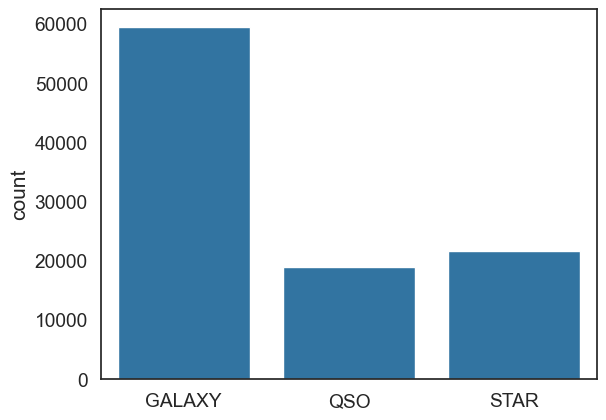

```python
fig = sns.countplot(x='class', data=dataset)
fig.set(xlabel=None)
```

We perform an oversampling here to balance the volume of different class type:

```python
x = df.drop(['class'], axis=1)
y = df['class']
```

```python
len(y)
```

```
90000
```

```python
from imblearn.over_sampling import SMOTE
from collections import Counter
```

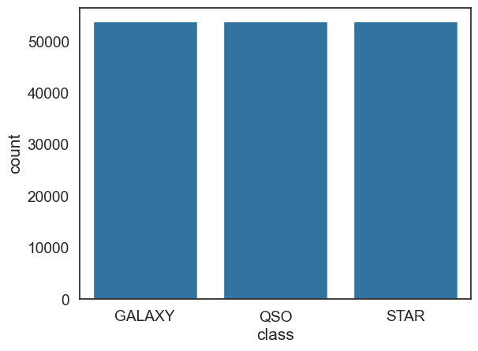

```python
x, y = SMOTE().fit_resample(x, y)
sns.countplot(x = y)
```

## Standardization

and we make a standardization to balance the scales of features:

```python
from sklearn.preprocessing import StandardScaler
```

```python
scaler = StandardScaler()
x = pd.DataFrame(scaler.fit_transform(x), columns=x.columns)

x.head()
```

|  | u | g | r | i | z | spec_obj_ID | redshift | plate | MJD |
| --- | --- | --- | --- | --- | --- | --- | --- | --- | --- |
| 0 | 1.022613 | 0.954801 | 0.379804 | -0.069890 | -0.134249 | 0.145665 | -0.086080 | 0.145704 | 0.345618 |
| 1 | 1.458388 | 1.252817 | 1.627827 | 1.099946 | 1.493552 | 1.685343 | 0.078360 | 1.685365 | 1.341837 |
| 2 | 1.693776 | 1.162868 | 0.502216 | 0.036929 | -0.045049 | -0.265077 | -0.075370 | -0.265049 | -0.075179 |
| 3 | 0.177991 | 1.758639 | 1.073298 | 0.712269 | 0.129143 | 1.254680 | 0.252901 | 1.254672 | 1.276121 |
| 4 | -1.130949 | -1.559110 | -1.841879 | -1.932744 | -2.009368 | 0.248408 | -0.676968 | 0.248393 | 0.253396 |

## Train test split

```python
from sklearn.model_selection import train_test_split
```

```python
x_train, x_test, y_train, y_test = train_test_split(x, y, test_size=0.3)
```

# Supervised Learning

## Logistic Regression

```python
from sklearn.linear_model import LogisticRegression
```

### Cross validation accuracy

```python
from sklearn.model_selection import cross_val_score
```

We draw the cv-accuracy here:

```python
results = []
for max_iter in range(1, 4):
    clf_lr = LogisticRegression(multi_class='multinomial', solver='newton-cg', max_iter=max_iter*100)
    clf_lr.fit(x_train, y_train)
    test_acc = clf_lr.score(x_test, y_test)
    cv_acc = np.mean(cross_val_score(clf_lr, x_train, y_train, cv=10))
    results.append([max_iter, cv_acc])
results = pd.DataFrame(
    data=results,
    columns=['max_iter', 'cv accuracy'],
)
```

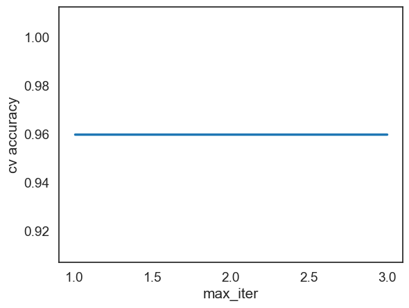

```python
sns.lineplot(
    x='max_iter',
    y='cv accuracy',
    data=results,
)
```

The parameter **max_iter** does not affect the cv-accuracy.

```python
clf_lr = LogisticRegression(multi_class='multinomial', solver='newton-cg', max_iter=200)
```

```
Mean accuracy: 0.9598424072425262
Std accuracy: 0.0023394849932139162
```

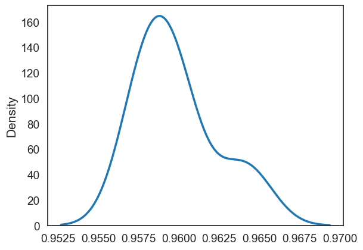

```python
scores_lr = cross_val_score(clf_lr, x_train, y_train, cv=10)
print(f'Mean accuracy: {np.mean(scores_lr)}')
print(f'Std accuracy: {np.std(scores_lr)}')
sns.kdeplot(scores_lr)
```

We calculate the test accuracy:

```python
clf_lr.fit(x_train,y_train)
clf_lr.score(x_test,y_test)
```

```
0.9595094051330759
```

## Decision Tree

```python
from sklearn.tree import DecisionTreeClassifier
```

We plot the cv-accuracy curve:

```python
results = []
for depth in range(6, 14):
    clf_dt = DecisionTreeClassifier(max_depth=depth)
    clf_dt.fit(x_train, y_train)
    test_acc = clf_dt.score(x_test, y_test)
    cv_acc = np.mean(cross_val_score(clf_dt, x_train, y_train, cv=10))
    results.append([depth, cv_acc])
results = pd.DataFrame(
    data=results,
    columns=['depth', 'cv accuracy'],
)
```

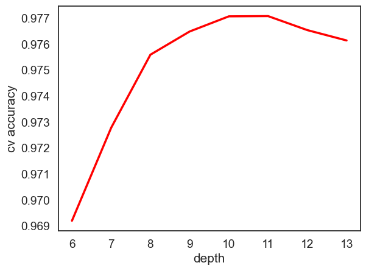

```python
sns.lineplot(
    x='depth',
    y='cv accuracy',
    color='r',
    data=results,
)
```

```python
clf_dt = DecisionTreeClassifier(max_depth=9)
```

```
Mean accuracy: 0.9765142993845795
Std accuracy: 0.0011246574450691714
```

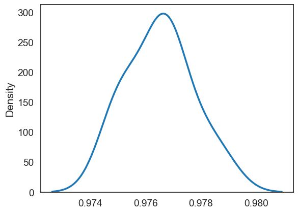

```python
scores_dt = cross_val_score(clf_dt, x_train, y_train, cv=10)
print(f'Mean accuracy: {np.mean(scores_dt)}')
print(f'Std accuracy: {np.std(scores_dt)}')
sns.kdeplot(scores_dt)
```

We calculate the test accuracy:

```python
clf_dt.fit(x_train,y_train)
clf_dt.score(x_test,y_test)
```

```
0.9762548780739609
```

## Random Forest

```python
from sklearn.ensemble import RandomForestClassifier
```

```python
clf_rf = RandomForestClassifier(n_estimators=10, max_depth=9)
clf_rf.fit(x_train, y_train)
```

```
RandomForestClassifier(max_depth=9, n_estimators=10)
```

```
Mean accuracy: 0.9777885941646641
Std accuracy: 0.0012495619342639752
```

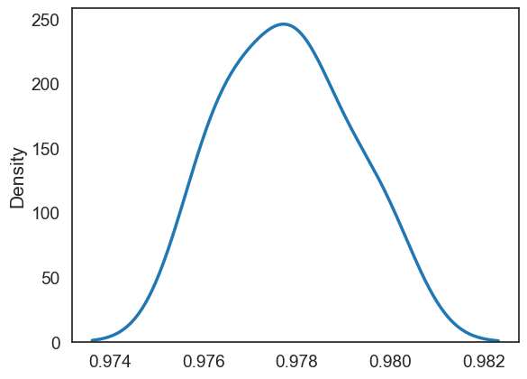

```python
scores_rf = cross_val_score(clf_rf, x_train, y_train, cv=10)
print(f'Mean accuracy: {np.mean(scores_rf)}')
print(f'Std accuracy: {np.std(scores_rf)}')
sns.kdeplot(scores_rf)
```

```python
clf_rf.score(x_test,y_test)
```

```
0.9779480085069481
```

The performance is better than the former decision tree.

## AdaBoost (Boosting)

```python
from sklearn.ensemble import AdaBoostClassifier
```

```python
clf_ada = AdaBoostClassifier(DecisionTreeClassifier(max_depth=10), n_estimators=50, learning_rate=1)
```

```
Mean accuracy: 0.9811689794857218
Std accuracy: 0.0011015092085718925
```

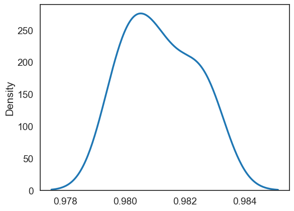

```python
scores_ada = cross_val_score(clf_ada, x_train, y_train, cv=10)
print(f'Mean accuracy: {np.mean(scores_ada)}')
print(f'Std accuracy: {np.std(scores_ada)}')
sns.kdeplot(scores_ada)
```

```python
clf_ada.fit(x_train,y_train)
clf_ada.score(x_test,y_test)
```

```
0.9814788048976895
```

### Hyper-parameter tuning

```python
from sklearn.model_selection import GridSearchCV
```

```python
param_grid = {
    'estimator__max_depth': [8,9,10],
    'n_estimators': [5, 25, 50],
    'learning_rate': [0.01, 0.1, 1.0]
}
clf_grid = GridSearchCV(estimator=clf_ada, param_grid=param_grid, cv=5)
clf_grid.fit(x_train, y_train)
```

```
GridSearchCV(cv=5,
             estimator=AdaBoostClassifier(estimator=DecisionTreeClassifier(max_depth=10),
                                          learning_rate=1),
             param_grid={'estimator__max_depth': [8, 9, 10],
                         'learning_rate': [0.01, 0.1, 1.0],
                         'n_estimators': [5, 25, 50]})
```

```python
clf_grid.best_params_
```

```
{'estimator__max_depth': 10, 'learning_rate': 0.1, 'n_estimators': 50}
```

# Unsupervised Learning

## PCA analysis

We do PCA analysis first to prepare for the clustering visualization:

```python
from sklearn.decomposition import PCA
```

```python
pca = PCA(n_components=3)
reduced_x = pd.DataFrame(pca.fit_transform(x), columns=['PC1', 'PC2', 'PC3'])
```

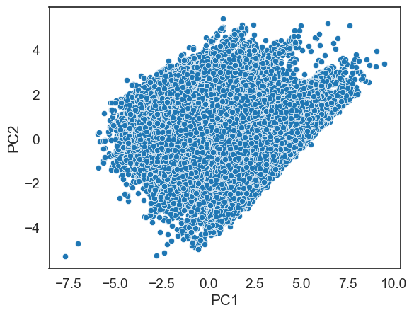

```python
sns.scatterplot(
    x='PC1',
    y='PC2',
    data=reduced_x,
)
```

## K-means clustering

```python
from sklearn.cluster import KMeans
```

```python
kmeans = KMeans(n_clusters=7, n_init=10)
kmeans.fit(x)
cluster = kmeans.predict(x)
```

```python
reduced_x['class'] = y
reduced_x['cluster'] = cluster
```

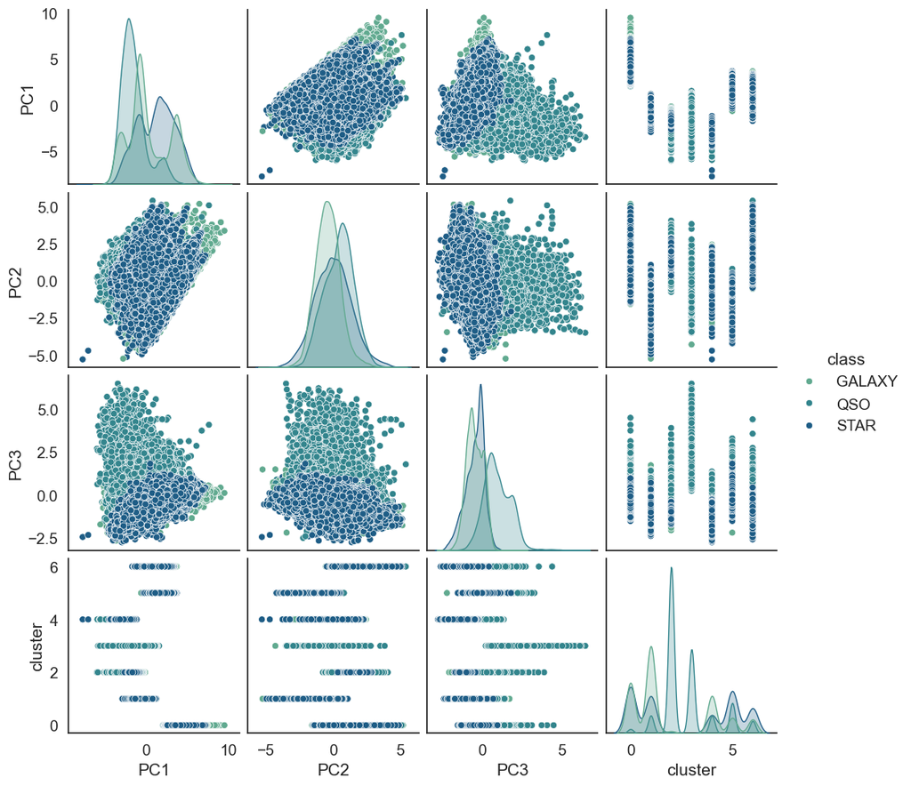

```python
sns.pairplot(reduced_x, hue='class', palette='crest')
```

As the **cluster-cluster** diagram suggested, there is a natural surjection from clusters to classes (clusters correspond to different peaks shown in the **PC1-PC1** diagram), by finding the major class inside each cluster, and we also see that the prediction of QSO is pretty good, which is interesting.

Here is the visualization of generated clusters:

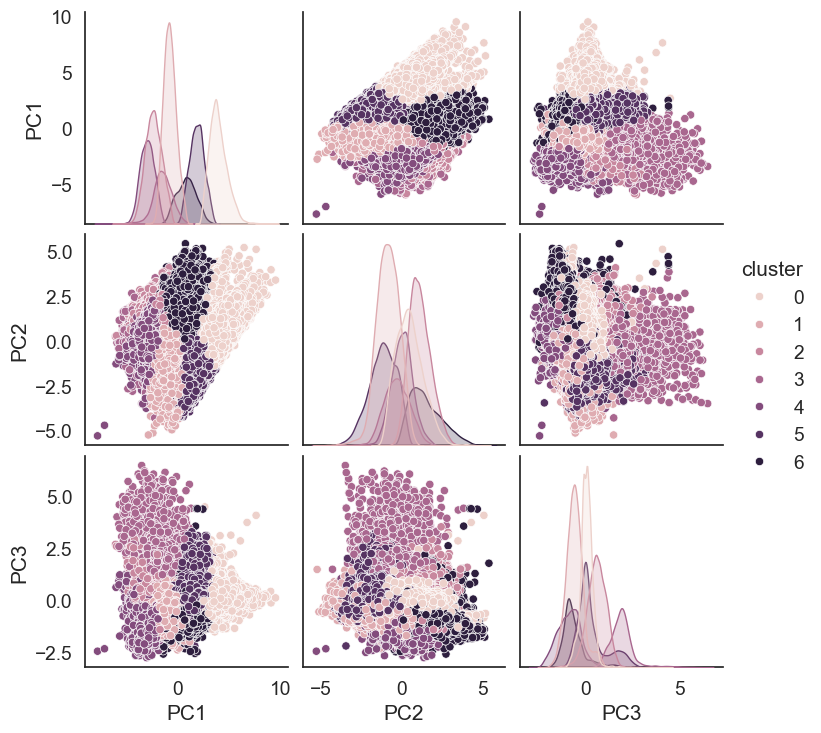

```python
sns.pairplot(reduced_x, hue='cluster')
```

To look the **cluster-cluster** diagram closer:

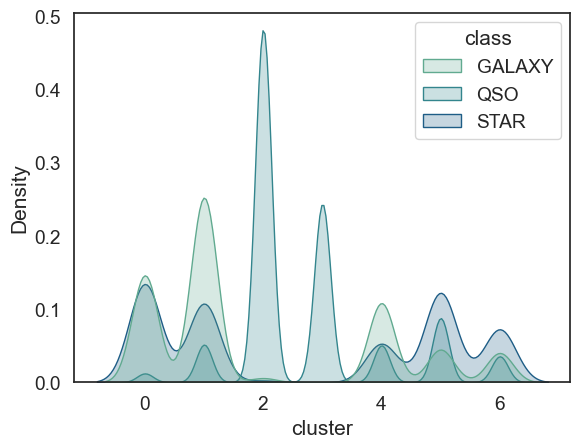

```python
sns.kdeplot(reduced_x, x='cluster', hue='class', palette='crest', fill=True)
```